# Final Project

- Adam Duke
- Whitney Schreiber
- MSCA 31008
- Utku Pamuksuz, PhD
- December 2021

### Dependencies

```python
import os
import pandas as pd
import numpy as np
import pandas_datareader.data as md
import datetime as dt
import seaborn as sns
import matplotlib.pyplot as plt
from rake_nltk import Rake
from sklearn.feature_extraction.text import TfidfVectorizer, CountVectorizer
from sklearn.decomposition import TruncatedSVD
from sklearn.cluster import KMeans, DBSCAN, AgglomerativeClustering
from sklearn.pipeline import make_pipeline
from sklearn.decomposition import TruncatedSVD
from sklearn.cluster import KMeans
from sklearn.pipeline import make_pipeline
from sklearn.metrics.pairwise import cosine_similarity
from sklearn.metrics import roc_curve, roc_auc_score, classification_report, auc
import yfinance as yf
```

### Data Import

#### Reddit

Reddit Channel Data Dictionary

- id (string): The id of the submission.
- author (string): The redditors username.
- created (datetime): Time the submission was created.
- retrieved (datetime): Time the submission was retrieved.
- edited (datetime): Time the submission was modified.
- pinned (integer): Whether or not the submission is pinned.
- archived (integer): Whether or not the submission is archived.
- locked (integer): Whether or not the submission is locked.
- removed (integer): Whether or not the submission is mod removed.
- deleted (integer): Whether or not the submission is user deleted.
- is_self (integer): Whether or not the submission is a text.
- is_video (integer): Whether or not the submission is a video.
- is_original_content (integer): Whether or not the submission has been set as original content.
- title (string): The title of the submission.
- link_flair_text (string): The submission link flairs text content.
- upvote_ratio (number): The percentage of upvotes from all votes on the submission.
- score (integer): The number of upvotes for the submission.
- gilded (integer): The number of gilded awards on the submission.
- total_awards_received (integer): The number of awards on the submission.
- num_comments (integer): The number of comments on the submission.
- num_crossposts (integer): The number of crossposts on the submission.
- selftext (string): The submission selftext on text posts.
- thumbnail (string): The submission thumbnail on image posts.
- shortlink (string): The submission short url.

```python
files = []
for folder, _, dataset in os.walk('data'):
    files = files + [os.path.join(folder, x) for x in dataset if x.endswith('.csv')]
raw_channels = { os.path.basename(os.path.dirname(x)): pd.read_csv(x) for x in files }
```

```python
list(raw_channels.keys())
```

```
['wallstreetbets',
 'stocks',
 'stockmarket',
 'securityanalysis',
 'robinhoodpennystocks',
 'robinhood',
 'personalfinance',
 'pennystocks',
 'options',
 'investing',
 'gme',
 'forex',
 'financialindependence',
 'finance']
```

```python
li = []
for channel in raw_channels.keys():
    df = raw_channels[channel]
    df['channel'] = channel
    li.append(df)
reddit = pd.concat(li, axis=0, ignore_index=True)
```

```python
rdf = reddit.copy()
channels = raw_channels.copy()
```

```python
raw_channels['wallstreetbets'].info()
```

```
<class 'pandas.core.frame.DataFrame'>
RangeIndex: 752945 entries, 0 to 752944
Data columns (total 24 columns):
 #   Column                 Non-Null Count   Dtype
---  ------                 --------------   -----
 0   id                     752945 non-null  object
 1   author                 752945 non-null  object
 2   created                752945 non-null  object
 3   retrieved              752945 non-null  object
 4   edited                 752945 non-null  object
 5   pinned                 752945 non-null  int64
 6   archived               752945 non-null  int64
 7   locked                 752945 non-null  int64
 8   removed                752945 non-null  int64
 9   deleted                752945 non-null  int64
```

[output cut: 16 more lines]

```python
pd.set_option('display.max_columns', None)
```

```python
print(rdf.shape)
rdf.head()
```

```
(1435425, 25)
```

|  | id | author | created | retrieved | edited | pinned | archived | locked | removed | deleted | is_self | is_video | is_original_content | title | link_flair_text | upvote_ratio | score | gilded | total_awards_received | num_comments | num_crossposts | selftext | thumbnail | shortlink | channel |
| --- | --- | --- | --- | --- | --- | --- | --- | --- | --- | --- | --- | --- | --- | --- | --- | --- | --- | --- | --- | --- | --- | --- | --- | --- | --- |
| 0 | ko124i | [deleted] | 2021-01-01 00:02:06 | 2021-02-02 21:52:13 | 1970-01-01 00:00:00 | 0 | 0 | 0 | 1 | 1 | 1 | 0 | 0 | 3k - 170k since March (Also, buy LIT!!) | Gain | 1.00 | 34 | 0 | 1 | 14 | 0 | [deleted] | default | https://redd.it/ko124i | wallstreetbets |
| 1 | ko12uq | [deleted] | 2021-01-01 00:03:20 | 2021-02-02 21:52:13 | 1970-01-01 00:00:00 | 0 | 0 | 0 | 1 | 1 | 0 | 0 | 0 | Got out of PLTR calls after learning about IV ... | Gain | 1.00 | 2 | 0 | 0 | 0 | 0 | [deleted] | default | https://redd.it/ko12uq | wallstreetbets |
| 2 | ko13df | [deleted] | 2021-01-01 00:04:11 | 2021-02-02 21:52:13 | 1970-01-01 00:00:00 | 0 | 0 | 0 | 1 | 1 | 0 | 0 | 0 | Hell of a headline | Meme | 0.88 | 13 | 0 | 0 | 7 | 0 | [deleted] | default | https://redd.it/ko13df | wallstreetbets |
| 3 | ko17yf | shirotimatim | 2021-01-01 00:11:51 | 2021-02-02 21:52:13 | 1970-01-01 00:00:00 | 0 | 0 | 0 | 0 | 0 | 0 | 0 | 0 | Top popular stocks on WSB too! Also, why they ... | News | 0.92 | 183 | 0 | 0 | 26 | 0 | NaN | https://b.thumbs.redditmedia.com/LmWdNB0W1qHT0... | https://redd.it/ko17yf | wallstreetbets |
| 4 | ko1a4i | WSBVoteBot | 2021-01-01 00:15:38 | 2021-02-02 21:52:13 | 1970-01-01 00:00:00 | 0 | 0 | 0 | 0 | 0 | 1 | 0 | 0 | WSBVoteBot Log for Jan 01 2021 | None | 0.50 | 0 | 0 | 0 | 19 | 0 | Every time a new submission is posted to walls... | self | https://redd.it/ko1a4i | wallstreetbets |

#### Yahoo Finance

```python
start = dt.datetime(2020, 1, 1)
end = dt.datetime(2021, 12, 1)

prices = yf.download(['GME'],start,end)
prices = prices.rename(columns={'Adj Close': 'Adj'})
```

```
[*********************100%***********************]  1 of 1 completed
```

```python
prices
```

| Date | Open | High | Low | Close | Adj | Volume |
| --- | --- | --- | --- | --- | --- | --- |
| 2020-01-02 | 6.140000 | 6.470000 | 6.070000 | 6.310000 | 6.310000 | 4453600 |
| 2020-01-03 | 6.210000 | 6.250000 | 5.840000 | 5.880000 | 5.880000 | 3543900 |
| 2020-01-06 | 5.800000 | 5.910000 | 5.600000 | 5.850000 | 5.850000 | 3394800 |
| 2020-01-07 | 5.770000 | 5.830000 | 5.440000 | 5.520000 | 5.520000 | 5228000 |
| 2020-01-08 | 5.490000 | 5.850000 | 5.410000 | 5.720000 | 5.720000 | 5629400 |
| ... | ... | ... | ... | ... | ... | ... |
| 2021-11-23 | 243.839996 | 252.199997 | 212.559998 | 213.899994 | 213.899994 | 3345200 |
| 2021-11-24 | 217.250000 | 223.990005 | 208.000000 | 211.779999 | 211.779999 | 1309400 |
| 2021-11-26 | 208.080002 | 211.729996 | 199.199997 | 199.720001 | 199.720001 | 1235300 |
| 2021-11-29 | 204.000000 | 207.910004 | 200.940002 | 202.009995 | 202.009995 | 1108800 |
| 2021-11-30 | 200.100006 | 203.949997 | 188.000000 | 196.210007 | 196.210007 | 1723900 |

483 rows × 6 columns

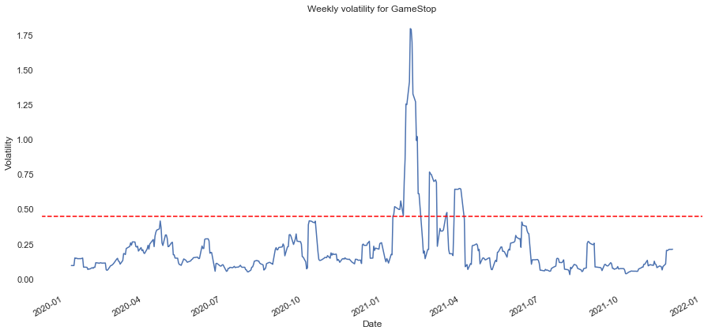

```python
# compute volatility using Pandas rolling and std methods
TRADING_DAYS = 7

returns = np.log(prices['Close']/prices['Close'].shift(1))
returns.fillna(0, inplace=True)
volatility = returns.rolling(window=TRADING_DAYS).std()*np.sqrt(TRADING_DAYS)

fig = plt.figure(figsize=(15, 7))
ax1 = fig.add_subplot(1, 1, 1)
volatility.plot(ax=ax1)
ax1.set_xlabel('Date')
ax1.set_ylabel('Volatility')
ax1.set_title('Weekly volatility for GameStop')
ax1.axhline(0.45, color='red', linestyle='--')
plt.show()
```

```python
sum(volatility>0.45)/len(volatility)
```

```
0.07453416149068323
```

```python
#-----------
# create target variable dataframe
#-----------

# create dataframe of the reddit date range
reddit_startdate = start
reddit_enddate = end
df_target = pd.DataFrame({'stock_date': pd.date_range(reddit_startdate, reddit_enddate)})

# left join GME volatility with reddit date range
# (to account for weekends/holidays)
df_target = df_target.merge(volatility,
                            left_on='stock_date',
                            right_on=volatility.index,
                            how='left'
                           )

# backfill days without stock market data
# (i.e. weekends are filled with the following Monday)
df_target.fillna(method='backfill', inplace=True)

# rename volatility metric
df_target = df_target.rename(columns={'Close': 'volatility'})

# use date - 1 to join with reddit data
df_target['reddit_date'] = df_target.stock_date.shift(1)

df_target
```

|  | stock_date | volatility | reddit_date |
| --- | --- | --- | --- |
| 0 | 2020-01-01 | 0.095461 | NaT |
| 1 | 2020-01-02 | 0.095461 | 2020-01-01 |
| 2 | 2020-01-03 | 0.095461 | 2020-01-02 |
| 3 | 2020-01-04 | 0.095461 | 2020-01-03 |
| 4 | 2020-01-05 | 0.095461 | 2020-01-04 |
| ... | ... | ... | ... |
| 696 | 2021-11-27 | 0.211264 | 2021-11-26 |
| 697 | 2021-11-28 | 0.211264 | 2021-11-27 |
| 698 | 2021-11-29 | 0.211264 | 2021-11-28 |
| 699 | 2021-11-30 | 0.212346 | 2021-11-29 |
| 700 | 2021-12-01 | NaN | 2021-11-30 |

701 rows × 3 columns

```python
df_target.loc[:,'reddit_date'] = pd.to_datetime(df_target['reddit_date']).dt.date
df_target.set_index('reddit_date', inplace=True)
```

```python
df_target
```

| reddit_date | stock_date | volatility |
| --- | --- | --- |
| NaN | 2020-01-01 | 0.095461 |
| 2020-01-01 | 2020-01-02 | 0.095461 |
| 2020-01-02 | 2020-01-03 | 0.095461 |
| 2020-01-03 | 2020-01-04 | 0.095461 |
| 2020-01-04 | 2020-01-05 | 0.095461 |
| ... | ... | ... |
| 2021-11-26 | 2021-11-27 | 0.211264 |
| 2021-11-27 | 2021-11-28 | 0.211264 |
| 2021-11-28 | 2021-11-29 | 0.211264 |
| 2021-11-29 | 2021-11-30 | 0.212346 |
| 2021-11-30 | 2021-12-01 | NaN |

701 rows × 2 columns

### Pre-processing

#### Reddit

##### Raw data

```python
rdf.info()
```

```
<class 'pandas.core.frame.DataFrame'>
RangeIndex: 1435425 entries, 0 to 1435424
Data columns (total 25 columns):
 #   Column                 Non-Null Count    Dtype
---  ------                 --------------    -----
 0   id                     1435425 non-null  object
 1   author                 1435425 non-null  object
 2   created                1435425 non-null  object
 3   retrieved              1435425 non-null  object
 4   edited                 1435425 non-null  object
 5   pinned                 1435425 non-null  int64
 6   archived               1435425 non-null  int64
 7   locked                 1435425 non-null  int64
 8   removed                1435425 non-null  int64
 9   deleted                1435425 non-null  int64
```

[output cut: 17 more lines]

##### Cleaning, Filtering, Transforming

```python
featuresOfInterest = [
    'created',
    'removed',
    'deleted',
    'is_self',
    'title',
    'link_flair_text',
    'upvote_ratio',
    'score',
    'gilded',
    'total_awards_received',
    'num_comments',
    'num_crossposts',
    'selftext',
    'channel']
rdf = rdf.loc[:,featuresOfInterest]
rdf.loc[:,'created'] = pd.to_datetime(rdf['created']).dt.date
boolfields = ['removed', 'deleted', 'is_self']
rdf.loc[:,boolfields] = rdf[boolfields].astype(bool)
strfields = ['title', 'link_flair_text', 'selftext']
rdf.loc[:,strfields] = rdf[strfields].astype(str)
rdf.loc[:,'selftext'].replace({'[deleted]': "", '[removed]': "", 'nan': ""}, inplace=True)
rdf.loc[:,'link_flair_text'] = rdf['link_flair_text'].apply(lambda x: x.encode('ascii', errors='ignore').strip().decode('utf-8'))
rdf.loc[:,'link_flair_text'].replace('None', np.NaN, inplace=True)
rdf.info()
```

```
<class 'pandas.core.frame.DataFrame'>
RangeIndex: 1435425 entries, 0 to 1435424
Data columns (total 14 columns):
 #   Column                 Non-Null Count    Dtype
---  ------                 --------------    -----
 0   created                1435425 non-null  object
 1   removed                1435425 non-null  bool
 2   deleted                1435425 non-null  bool
 3   is_self                1435425 non-null  bool
 4   title                  1435425 non-null  object
 5   link_flair_text        1257897 non-null  object
 6   upvote_ratio           1435425 non-null  float64
 7   score                  1435425 non-null  int64
 8   gilded                 1435425 non-null  int64
 9   total_awards_received  1435425 non-null  int64
 10  num_comments           1435425 non-null  int64
 11  num_crossposts         1435425 non-null  int64
 12  selftext               1435425 non-null  object
 13  channel                1435425 non-null  object
dtypes: bool(3), float64(1), int64(5), object(5)
memory usage: 124.6+ MB
```

##### Parallel rake the data

```python
import multiprocessing as mp
from multiprocessing import Pool, get_context, set_start_method
import time
from Specials import RakeSegment # custom external module definitions for multiprocessing dispatch
```

```python
set_start_method("spawn")
```

```python
df = rdf.iloc[:,:].copy()
cores = int(mp.cpu_count()/2)
df_split = np.array_split(df, cores*2)
start = time.time()
with get_context("spawn").Pool() as pool:
    df_ = pd.concat(pool.map(RakeSegment, df_split))
end = time.time()
```

```python
print("{} minutes".format((end-start)/60))
```

```
124.75585321585338 minutes
```

[figure not shown]

```python
df_.shape
```

```
(1435425, 15)
```

```python
df_.to_csv('dfraked.csv')
```

```python
df = pd.read_csv('dfraked.csv', index_col=0, low_memory=False, parse_dates=['created'])
```

```python
df.info()
```

```
<class 'pandas.core.frame.DataFrame'>
Int64Index: 1435425 entries, 0 to 1435424
Data columns (total 15 columns):
 #   Column                 Non-Null Count    Dtype
---  ------                 --------------    -----
 0   created                1435425 non-null  datetime64[ns]
 1   removed                1435425 non-null  bool
 2   deleted                1435425 non-null  bool
 3   is_self                1435425 non-null  bool
 4   title                  1435421 non-null  object
 5   link_flair_text        1203105 non-null  object
 6   upvote_ratio           1435425 non-null  float64
 7   score                  1435425 non-null  int64
 8   gilded                 1435425 non-null  int64
 9   total_awards_received  1435425 non-null  int64
 10  num_comments           1435425 non-null  int64
 11  num_crossposts         1435425 non-null  int64
 12  selftext               292995 non-null   object
 13  channel                1435425 non-null  object
 14  alltext                1433134 non-null  object
dtypes: bool(3), datetime64[ns](1), float64(1), int64(5), object(5)
memory usage: 146.5+ MB
```

##### Serially rake the data

too slow

```python
# df = rdf.loc[rdf['channel']=='gme',:].iloc[0:10000,:].copy()
# r = Rake()
# df.loc[:,['alltext']] = str()
# for index, row in df.iterrows():
#     # title keywords
#     title = row['title'].lower()
#     r.extract_keywords_from_text(title)
#     title_kws = list(r.get_word_degrees().keys())
#     # selftext keywords
#     selftext = row['selftext'].lower()
#     r.extract_keywords_from_text(selftext)
#     selftext_kws = list(r.get_word_degrees().keys())
#     # combine keywords
#     df.loc[index,'alltext'] = ' '.join(title_kws + selftext_kws)
```

```python
df.drop(columns=['title', 'selftext', 'is_self', 'deleted', 'removed'], inplace=True)
```

```python
df
```

|  | created | link_flair_text | upvote_ratio | score | gilded | total_awards_received | num_comments | num_crossposts | channel | alltext |
| --- | --- | --- | --- | --- | --- | --- | --- | --- | --- | --- |
| 0 | 2021-01-01 | Gain | 1.00 | 34 | 0 | 1 | 14 | 0 | wallstreetbets | also buy lit !!) 170k since march 3k |
| 1 | 2021-01-01 | Gain | 1.00 | 2 | 0 | 0 | 0 | 0 | wallstreetbets | thanks happy new year fam tsla learning ending... |
| 2 | 2021-01-01 | Meme | 0.88 | 13 | 0 | 0 | 7 | 0 | wallstreetbets | headline hell |
| 3 | 2021-01-01 | News | 0.92 | 183 | 0 | 0 | 26 | 0 | wallstreetbets | also boy pltr top popular stocks give fucking ... |
| 4 | 2021-01-01 | NaN | 0.50 | 0 | 0 | 0 | 19 | 0 | wallstreetbets | jan 01 2021 wsbvotebot log r com messages new ... |
| ... | ... | ... | ... | ... | ... | ... | ... | ... | ... | ... |
| 1435420 | 2021-11-21 | NaN | 0.92 | 59 | 0 | 0 | 1 | 0 | finance | 12 bln takeover proposal binding kkr makes non... |
| 1435421 | 2021-11-21 | NaN | 1.00 | 1 | 0 | 0 | 0 | 0 | finance | “ buy nothing ” groups gain popularity antidot... |
| 1435422 | 2021-11-21 | NaN | 1.00 | 1 | 0 | 0 | 0 | 0 | finance | n26 withdraws 2020 wp com uploads fintechnews ... |
| 1435423 | 2021-11-21 | NaN | 0.83 | 4 | 0 | 0 | 2 | 0 | finance | manufactured housing industry sees opening hom... |
| 1435424 | 2021-11-21 | NaN | 1.00 | 1 | 0 | 0 | 0 | 0 | finance | selling start new week – currency strength eur... |

1435425 rows × 10 columns

Dummy variable encode top 10 link_flair_text

```python
lft = df.groupby('link_flair_text').agg('count')[['created']].sort_values(
    by='created', ascending=False).iloc[0:10,:].index.values
lft
```

```
array(['Discussion', 'YOLO', 'Meme', 'News', 'Gain', 'DD', 'Memes',
       'Loss', 'Shitpost', 'Fluff'], dtype=object)
```

```python
dfDummyLFT = pd.get_dummies(data=df, columns=['link_flair_text'], dtype=bool)
```

```python
df = df.join(dfDummyLFT[dfDummyLFT.columns.intersection('link_flair_text_'+lft).values])
```

```python
df.drop(columns=['link_flair_text'], inplace=True)
```

```python
df.head()
```

|  | created | upvote_ratio | score | gilded | total_awards_received | num_comments | num_crossposts | channel | alltext | link_flair_text_DD | link_flair_text_Discussion | link_flair_text_Fluff | link_flair_text_Gain | link_flair_text_Loss | link_flair_text_Meme | link_flair_text_Memes | link_flair_text_News | link_flair_text_Shitpost | link_flair_text_YOLO |
| --- | --- | --- | --- | --- | --- | --- | --- | --- | --- | --- | --- | --- | --- | --- | --- | --- | --- | --- | --- |
| 0 | 2021-01-01 | 1.00 | 34 | 0 | 1 | 14 | 0 | wallstreetbets | also buy lit !!) 170k since march 3k | False | False | False | True | False | False | False | False | False | False |
| 1 | 2021-01-01 | 1.00 | 2 | 0 | 0 | 0 | 0 | wallstreetbets | thanks happy new year fam tsla learning ending... | False | False | False | True | False | False | False | False | False | False |
| 2 | 2021-01-01 | 0.88 | 13 | 0 | 0 | 7 | 0 | wallstreetbets | headline hell | False | False | False | False | False | True | False | False | False | False |
| 3 | 2021-01-01 | 0.92 | 183 | 0 | 0 | 26 | 0 | wallstreetbets | also boy pltr top popular stocks give fucking ... | False | False | False | False | False | False | False | True | False | False |
| 4 | 2021-01-01 | 0.50 | 0 | 0 | 0 | 19 | 0 | wallstreetbets | jan 01 2021 wsbvotebot log r com messages new ... | False | False | False | False | False | False | False | False | False | False |

Dummy variable encode channel

```python
# df = pd.get_dummies(data=df, columns=['channel'], dtype=bool)
```

##### Filter to GME channel

```python
gmedf = df[df['channel']=='gme'].copy()
```

```python
gmedf.drop(columns=['channel'], inplace=True)
```

```python
gmedf.head()
```

|  | created | upvote_ratio | score | gilded | total_awards_received | num_comments | num_crossposts | alltext | link_flair_text_DD | link_flair_text_Discussion | link_flair_text_Fluff | link_flair_text_Gain | link_flair_text_Loss | link_flair_text_Meme | link_flair_text_Memes | link_flair_text_News | link_flair_text_Shitpost | link_flair_text_YOLO |
| --- | --- | --- | --- | --- | --- | --- | --- | --- | --- | --- | --- | --- | --- | --- | --- | --- | --- | --- |
| 1142377 | 2021-01-01 | 1.00 | 10 | 0 | 0 | 0 | 0 | moon 🚀🚀 gme | False | False | False | False | False | False | False | False | False | False |
| 1142378 | 2021-01-04 | 0.59 | 5 | 0 | 0 | 6 | 0 | see need gme 🚀🚀🚀🚀🚀🚀 watching position right aw... | False | False | False | False | False | False | False | False | False | False |
| 1142379 | 2021-01-04 | 0.93 | 13 | 0 | 0 | 1 | 0 | short squeeze incoming 🚀🚀🚀🚀🚀🚀🚀 | False | False | False | False | False | False | False | False | False | False |
| 1142380 | 2021-01-05 | 0.50 | 0 | 0 | 0 | 5 | 0 | 💰 gme extreme pump coming convinced v take mjh... | False | False | False | False | False | False | False | False | False | False |
| 1142381 | 2021-01-06 | 0.97 | 31 | 0 | 1 | 4 | 0 | complaint submit already know must part sister... | False | False | False | False | False | False | False | False | False | False |

### Feature Engineering

```python
dffe = gmedf
```

```python
dffe.dropna(inplace=True)
```

#### Count Vectorizer

```python
corpus = dffe['alltext']
ctvec = CountVectorizer()
ctvec_X = ctvec.fit_transform(corpus)
words = ctvec.get_feature_names()
```

#### TF-IDF Vectorizer

```python
corpus = dffe['alltext']
tfidf = TfidfVectorizer()
tfidf_X = tfidf.fit_transform(corpus)
words = tfidf.get_feature_names()
```

#### Truncated SVD n-componenets selection

```python
tsvdRecords = pd.DataFrame(columns=['N', 'CV', 'TFIDF'])
nrange = [n for n in [25, 50, 75, 100]]
for n in nrange:
    svd = TruncatedSVD(n_components=n)
    svd.fit_transform(ctvec_X)
    sc = sum(svd.explained_variance_ratio_)
    svd.fit_transform(tfidf_X)
    st = sum(svd.explained_variance_ratio_)
    tsvdRecords = tsvdRecords.append({'N': n, 'CV': sc, 'TFIDF': st}, ignore_index=True)
```

```python
tsvdRecords
```

|  | N | CV | TFIDF |
| --- | --- | --- | --- |
| 0 | 25.0 | 0.154687 | 0.066942 |
| 1 | 50.0 | 0.206123 | 0.105744 |
| 2 | 75.0 | 0.244709 | 0.136561 |
| 3 | 100.0 | 0.275428 | 0.161941 |

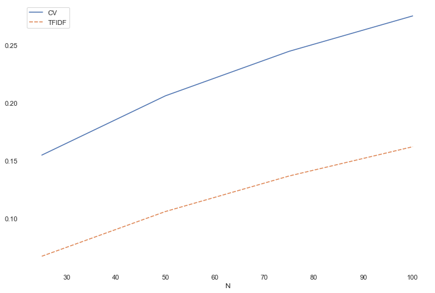

```python
# tsvdRecords.set_index('N', inplace=True)
sns.set(rc={'figure.figsize':(12,8)})
sns.set(rc={'axes.facecolor':'white', 'figure.facecolor':'white'})
sns.lineplot(data=tsvdRecords)
```

#### Pipeline (TF-IDF, tSVD, KMeans)

```python
svd = TruncatedSVD(n_components=100)
```

##### n-clusters selection

```python
inertias = pd.DataFrame(columns=['N', 'inertia_tfidf', 'inertia_ctvec'])
for n in [2,4,8,16,32,64]:
    k = KMeans(n_clusters=n, random_state=0)
    p = make_pipeline(svd, k)
    p.fit(tfidf_X)
    p.predict(tfidf_X)
    i1 = k.inertia_
    p.fit(ctvec_X)
    p.predict(ctvec_X)
    i2 = k.inertia_
    inertias = inertias.append({'N': n, 'inertia_tfidf': i1, 'inertia_ctvec': i2}, ignore_index=True)
inertias.set_index('N', inplace=True)
```

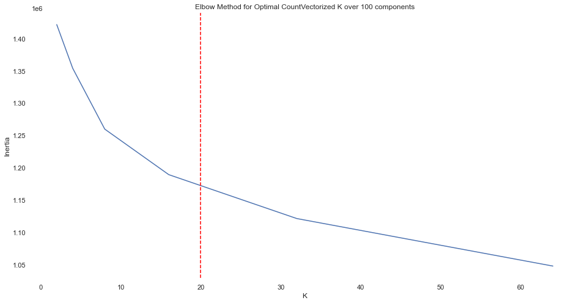

```python
plt.figure(figsize=(16,8))
plt.plot(inertias['inertia_ctvec'])
plt.xlabel('K')
plt.ylabel('Inertia')
plt.title('Elbow Method for Optimal CountVectorized K over {} components'.format(100))
plt.axvline(20, linestyle='--', color='red')
plt.show()
```

[figure not shown]

```python
plt.figure(figsize=(16,8))
plt.plot(inertias['inertia_ifidf'])
plt.xlabel('K')
plt.ylabel('Inertia')
plt.title('Elbow Method for Optimal TFIDF K over {} components'.format(100))
plt.axvline(20, linestyle='--', color='red')
plt.show()
```

```python
kmeans = KMeans(n_clusters=20)
pipeline = make_pipeline(svd, kmeans)
```

```python
pipeline.fit(tfidf_X)
labels_tfidf = pipeline.predict(tfidf_X)
pipeline.fit(ctvec_X)
labels_ctvec = pipeline.predict(ctvec_X)
```

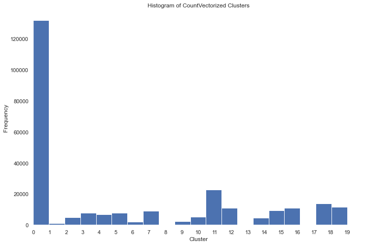

```python
plt.hist(labels_ctvec, bins=20)
plt.xlabel('Cluster')
plt.ylabel('Frequency')
plt.xlim(0,20)
plt.xticks(np.arange(0,20,1))
plt.title('Histogram of CountVectorized Clusters')
plt.show()
```

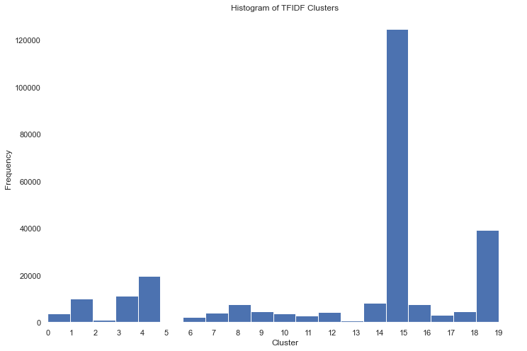

```python
plt.hist(labels_tfidf, bins=20)
plt.xlabel('Cluster')
plt.ylabel('Frequency')
plt.xlim(0,20)
plt.xticks(np.arange(0,20,1))
plt.title('Histogram of TFIDF Clusters')
plt.show()
```

```python
df_ctvec = dffe.copy()
df_tfidf = dffe.copy()
```

```python
df_ctvec['cluster'] = labels_ctvec
df_tfidf['cluster'] = labels_tfidf
```

```python
df_ctvec = pd.get_dummies(data=df_ctvec, columns=['cluster'], dtype=bool)
df_tfidf = pd.get_dummies(data=df_tfidf, columns=['cluster'], dtype=bool)
```

```python
df_ctvec.loc[:,'created'] = pd.to_datetime(df_ctvec['created']).dt.date
df_tfidf.loc[:,'created'] = pd.to_datetime(df_tfidf['created']).dt.date
```

```python
df_ctvec.head()
```

|  | created | upvote_ratio | score | gilded | total_awards_received | num_comments | num_crossposts | alltext | link_flair_text_DD | link_flair_text_Discussion | link_flair_text_Fluff | link_flair_text_Gain | link_flair_text_Loss | link_flair_text_Meme | link_flair_text_Memes | link_flair_text_News | link_flair_text_Shitpost | link_flair_text_YOLO | cluster_0 | cluster_1 | cluster_2 | cluster_3 | cluster_4 | cluster_5 | cluster_6 | cluster_7 | cluster_8 | cluster_9 | cluster_10 | … |
| --- | --- | --- | --- | --- | --- | --- | --- | --- | --- | --- | --- | --- | --- | --- | --- | --- | --- | --- | --- | --- | --- | --- | --- | --- | --- | --- | --- | --- | --- | --- |
| 1142377 | 2021-01-01 | 1.00 | 10 | 0 | 0 | 0 | 0 | moon 🚀🚀 gme | False | False | False | False | False | False | False | False | False | False | False | False | False | False | True | False | False | False | False | False | False | … |
| 1142378 | 2021-01-04 | 0.59 | 5 | 0 | 0 | 6 | 0 | see need gme 🚀🚀🚀🚀🚀🚀 watching position right aw... | False | False | False | False | False | False | False | False | False | False | False | False | False | False | False | False | False | False | False | False | False | … |
| 1142379 | 2021-01-04 | 0.93 | 13 | 0 | 0 | 1 | 0 | short squeeze incoming 🚀🚀🚀🚀🚀🚀🚀 | False | False | False | False | False | False | False | False | False | False | True | False | False | False | False | False | False | False | False | False | False | … |
| 1142380 | 2021-01-05 | 0.50 | 0 | 0 | 0 | 5 | 0 | 💰 gme extreme pump coming convinced v take mjh... | False | False | False | False | False | False | False | False | False | False | False | False | False | True | False | False | False | False | False | False | False | … |
| 1142381 | 2021-01-06 | 0.97 | 31 | 0 | 1 | 4 | 0 | complaint submit already know must part sister... | False | False | False | False | False | False | False | False | False | False | True | False | False | False | False | False | False | False | False | False | False | … |

```python
df_tfidf.head()
```

|  | created | upvote_ratio | score | gilded | total_awards_received | num_comments | num_crossposts | alltext | link_flair_text_DD | link_flair_text_Discussion | link_flair_text_Fluff | link_flair_text_Gain | link_flair_text_Loss | link_flair_text_Meme | link_flair_text_Memes | link_flair_text_News | link_flair_text_Shitpost | link_flair_text_YOLO | cluster_0 | cluster_1 | cluster_2 | cluster_3 | cluster_4 | cluster_5 | cluster_6 | cluster_7 | cluster_8 | cluster_9 | cluster_10 | … |
| --- | --- | --- | --- | --- | --- | --- | --- | --- | --- | --- | --- | --- | --- | --- | --- | --- | --- | --- | --- | --- | --- | --- | --- | --- | --- | --- | --- | --- | --- | --- |
| 1142377 | 2021-01-01 | 1.00 | 10 | 0 | 0 | 0 | 0 | moon 🚀🚀 gme | False | False | False | False | False | False | False | False | False | False | True | False | False | False | False | False | False | False | False | False | False | … |
| 1142378 | 2021-01-04 | 0.59 | 5 | 0 | 0 | 6 | 0 | see need gme 🚀🚀🚀🚀🚀🚀 watching position right aw... | False | False | False | False | False | False | False | False | False | False | False | False | False | False | True | False | False | False | False | False | False | … |
| 1142379 | 2021-01-04 | 0.93 | 13 | 0 | 0 | 1 | 0 | short squeeze incoming 🚀🚀🚀🚀🚀🚀🚀 | False | False | False | False | False | False | False | False | False | False | False | False | False | False | False | False | False | False | False | False | False | … |
| 1142380 | 2021-01-05 | 0.50 | 0 | 0 | 0 | 5 | 0 | 💰 gme extreme pump coming convinced v take mjh... | False | False | False | False | False | False | False | False | False | False | False | False | False | False | True | False | False | False | False | False | False | … |
| 1142381 | 2021-01-06 | 0.97 | 31 | 0 | 1 | 4 | 0 | complaint submit already know must part sister... | False | False | False | False | False | False | False | False | False | False | False | False | False | False | False | False | False | False | False | False | False | … |

```python
modelingdf_ctvec = df_ctvec.join(df_target['volatility'], on='created', how='left')
modelingdf_tfidf = df_tfidf.join(df_target['volatility'], on='created', how='left')
```

```python
modelingdf_ctvec['mania'] = modelingdf_ctvec['volatility'] >= 0.45
modelingdf_ctvec.drop(columns=['volatility', 'created', 'alltext'], inplace=True)
modelingdf_tfidf['mania'] = modelingdf_tfidf['volatility'] >= 0.45
modelingdf_tfidf.drop(columns=['volatility', 'created', 'alltext'], inplace=True)
```

```python
modelingdf_ctvec
```

|  | upvote_ratio | score | gilded | total_awards_received | num_comments | num_crossposts | link_flair_text_DD | link_flair_text_Discussion | link_flair_text_Fluff | link_flair_text_Gain | link_flair_text_Loss | link_flair_text_Meme | link_flair_text_Memes | link_flair_text_News | link_flair_text_Shitpost | link_flair_text_YOLO | cluster_0 | cluster_1 | cluster_2 | cluster_3 | cluster_4 | cluster_5 | cluster_6 | cluster_7 | cluster_8 | cluster_9 | cluster_10 | cluster_11 | cluster_12 | … |
| --- | --- | --- | --- | --- | --- | --- | --- | --- | --- | --- | --- | --- | --- | --- | --- | --- | --- | --- | --- | --- | --- | --- | --- | --- | --- | --- | --- | --- | --- | --- |
| 1142377 | 1.00 | 10 | 0 | 0 | 0 | 0 | False | False | False | False | False | False | False | False | False | False | False | False | False | False | True | False | False | False | False | False | False | False | False | … |
| 1142378 | 0.59 | 5 | 0 | 0 | 6 | 0 | False | False | False | False | False | False | False | False | False | False | False | False | False | False | False | False | False | False | False | False | False | True | False | … |
| 1142379 | 0.93 | 13 | 0 | 0 | 1 | 0 | False | False | False | False | False | False | False | False | False | False | True | False | False | False | False | False | False | False | False | False | False | False | False | … |
| 1142380 | 0.50 | 0 | 0 | 0 | 5 | 0 | False | False | False | False | False | False | False | False | False | False | False | False | False | True | False | False | False | False | False | False | False | False | False | … |
| 1142381 | 0.97 | 31 | 0 | 1 | 4 | 0 | False | False | False | False | False | False | False | False | False | False | True | False | False | False | False | False | False | False | False | False | False | False | False | … |
| ... | ... | ... | ... | ... | ... | ... | ... | ... | ... | ... | ... | ... | ... | ... | ... | ... | ... | ... | ... | ... | ... | ... | ... | ... | ... | ... | ... | ... | ... | … |
| 1406221 | 1.00 | 12 | 0 | 0 | 0 | 0 | False | True | False | False | False | False | False | False | False | False | False | False | False | False | False | False | False | False | False | False | True | False | False | … |
| 1406222 | 1.00 | 12 | 0 | 0 | 2 | 0 | False | False | True | False | False | False | False | False | False | False | True | False | False | False | False | False | False | False | False | False | False | False | False | … |
| 1406223 | 1.00 | 2 | 0 | 0 | 0 | 0 | False | False | False | False | False | False | False | False | False | False | True | False | False | False | False | False | False | False | False | False | False | False | False | … |
| 1406224 | 1.00 | 13 | 0 | 0 | 2 | 0 | False | False | False | False | False | False | False | False | False | False | True | False | False | False | False | False | False | False | False | False | False | False | False | … |
| 1406225 | 0.92 | 11 | 0 | 0 | 3 | 0 | False | False | False | False | False | False | False | False | False | False | True | False | False | False | False | False | False | False | False | False | False | False | False | … |

263362 rows × 37 columns

```python
modelingdf_tfidf
```

|  | upvote_ratio | score | gilded | total_awards_received | num_comments | num_crossposts | link_flair_text_DD | link_flair_text_Discussion | link_flair_text_Fluff | link_flair_text_Gain | link_flair_text_Loss | link_flair_text_Meme | link_flair_text_Memes | link_flair_text_News | link_flair_text_Shitpost | link_flair_text_YOLO | cluster_0 | cluster_1 | cluster_2 | cluster_3 | cluster_4 | cluster_5 | cluster_6 | cluster_7 | cluster_8 | cluster_9 | cluster_10 | cluster_11 | cluster_12 | … |
| --- | --- | --- | --- | --- | --- | --- | --- | --- | --- | --- | --- | --- | --- | --- | --- | --- | --- | --- | --- | --- | --- | --- | --- | --- | --- | --- | --- | --- | --- | --- |
| 1142377 | 1.00 | 10 | 0 | 0 | 0 | 0 | False | False | False | False | False | False | False | False | False | False | True | False | False | False | False | False | False | False | False | False | False | False | False | … |
| 1142378 | 0.59 | 5 | 0 | 0 | 6 | 0 | False | False | False | False | False | False | False | False | False | False | False | False | False | False | True | False | False | False | False | False | False | False | False | … |
| 1142379 | 0.93 | 13 | 0 | 0 | 1 | 0 | False | False | False | False | False | False | False | False | False | False | False | False | False | False | False | False | False | False | False | False | False | False | False | … |
| 1142380 | 0.50 | 0 | 0 | 0 | 5 | 0 | False | False | False | False | False | False | False | False | False | False | False | False | False | False | True | False | False | False | False | False | False | False | False | … |
| 1142381 | 0.97 | 31 | 0 | 1 | 4 | 0 | False | False | False | False | False | False | False | False | False | False | False | False | False | False | False | False | False | False | False | False | False | False | False | … |
| ... | ... | ... | ... | ... | ... | ... | ... | ... | ... | ... | ... | ... | ... | ... | ... | ... | ... | ... | ... | ... | ... | ... | ... | ... | ... | ... | ... | ... | ... | … |
| 1406221 | 1.00 | 12 | 0 | 0 | 0 | 0 | False | True | False | False | False | False | False | False | False | False | False | False | False | False | False | False | False | False | False | False | False | False | False | … |
| 1406222 | 1.00 | 12 | 0 | 0 | 2 | 0 | False | False | True | False | False | False | False | False | False | False | False | False | False | False | False | False | False | False | False | False | False | False | False | … |
| 1406223 | 1.00 | 2 | 0 | 0 | 0 | 0 | False | False | False | False | False | False | False | False | False | False | False | False | False | False | False | False | False | False | False | False | False | False | False | … |
| 1406224 | 1.00 | 13 | 0 | 0 | 2 | 0 | False | False | False | False | False | False | False | False | False | False | False | False | False | False | False | False | False | False | False | False | False | False | False | … |
| 1406225 | 0.92 | 11 | 0 | 0 | 3 | 0 | False | False | False | False | False | False | False | False | False | False | False | False | False | False | False | False | False | False | False | False | False | False | False | … |

263362 rows × 37 columns

### Modeling

```python
from sklearn.tree import DecisionTreeClassifier
from sklearn.model_selection import train_test_split, GridSearchCV
from sklearn.metrics import accuracy_score
```

```python
target_feature = 'mania'
X_ctvec = modelingdf_ctvec.drop(columns=[target_feature])
Y_ctvec = modelingdf_ctvec[target_feature]
X_tfidf = modelingdf_tfidf.drop(columns=[target_feature])
Y_tfidf = modelingdf_tfidf[target_feature]
```

```python
(x_train_ctvec, x_test_ctvec, y_train_ctvec, y_test_ctvec) = train_test_split(X_ctvec, Y_ctvec, test_size=.20, random_state=0)
(x_train_tfidf, x_test_tfidf, y_train_tfidf, y_test_tfidf) = train_test_split(X_tfidf, Y_tfidf, test_size=.20, random_state=0)
```

#### Decision Tree

```python
param_dict = {
    'max_depth': [4, 8, 12, 16, 20],
    'min_samples_leaf': [1, 5, 10, 15, 20],
    'random_state': [0]
}
```

```python
dtgrid_ctvec = GridSearchCV(
    DecisionTreeClassifier(),
    param_grid=param_dict,
    verbose=1,
    n_jobs=4)
dtgrid_ctvec.fit(x_train_ctvec, y_train_ctvec)
```

```
Fitting 5 folds for each of 25 candidates, totalling 125 fits
```

[output not shown]

```python
dtgrid_tfidf = GridSearchCV(
    DecisionTreeClassifier(),
    param_grid=param_dict,
    verbose=1,
    n_jobs=4)
dtgrid_tfidf.fit(x_train_tfidf, y_train_tfidf)
```

```
Fitting 5 folds for each of 25 candidates, totalling 125 fits
```

```
GridSearchCV(estimator=DecisionTreeClassifier(), n_jobs=4,
             param_grid={'max_depth': [4, 8, 12, 16, 20],
                         'min_samples_leaf': [1, 5, 10, 15, 20],
                         'random_state': [0]},
             verbose=1)
```

```python
print(dtgrid_ctvec.best_params_)
print(dtgrid_ctvec.best_estimator_)
print(dtgrid_ctvec.best_score_)
```

[output not shown]

```python
print(dtgrid_tfidf.best_params_)
print(dtgrid_tfidf.best_estimator_)
print(dtgrid_tfidf.best_score_)
```

```
{'max_depth': 4, 'min_samples_leaf': 1, 'random_state': 0}
DecisionTreeClassifier(max_depth=4, random_state=0)
0.6845492629954852
```

```python
dty_pred_ctvec = dtgrid_ctvec.best_estimator_.predict(x_test_ctvec)
dty_pred_tfidf = dtgrid_tfidf.best_estimator_.predict(x_test_tfidf)
```

```python
print(accuracy_score(y_test_ctvec, dty_pred_ctvec))
print(accuracy_score(y_test_tfidf, dty_pred_tfidf))
```

```
0.6872970971845158
0.6833861750802118
```

##### CountVectorizer Decision Tree Report

```python
print(classification_report(y_test_ctvec, dty_pred_ctvec))
```

```
              precision    recall  f1-score   support

       False       0.69      0.97      0.81     35877
        True       0.57      0.08      0.14     16796

    accuracy                           0.69     52673
   macro avg       0.63      0.53      0.47     52673
weighted avg       0.65      0.69      0.60     52673
```

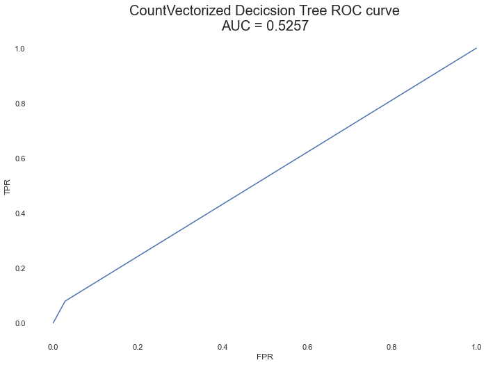

```python
from sklearn.metrics import auc
fpr, tpr, _ = roc_curve(y_test_ctvec, dty_pred_ctvec)
plt.clf()
plt.plot(fpr, tpr)
plt.xlabel('FPR')
plt.ylabel('TPR')
plt.title('CountVectorized Decicsion Tree ROC curve\nAUC = {:.4f}'.format(
    auc(*roc_curve(y_test_ctvec, dty_pred_ctvec)[0:2])), fontdict = {'fontsize' : 20})
plt.show()
```

##### TF-IDF Decision Tree Report

```python
print(classification_report(y_test_tfidf, dty_pred_tfidf))
```

```
              precision    recall  f1-score   support

       False       0.68      1.00      0.81     35877
        True       0.63      0.02      0.03     16796

    accuracy                           0.68     52673
   macro avg       0.65      0.51      0.42     52673
weighted avg       0.67      0.68      0.56     52673
```

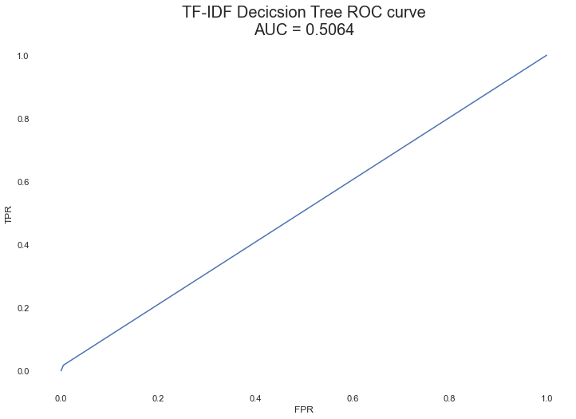

```python
from sklearn.metrics import auc
fpr, tpr, _ = roc_curve(y_test_tfidf, dty_pred_tfidf)
plt.clf()
plt.plot(fpr, tpr)
plt.xlabel('FPR')
plt.ylabel('TPR')
plt.title('TF-IDF Decicsion Tree ROC curve\nAUC = {:.4f}'.format(
    auc(*roc_curve(y_test_tfidf, dty_pred_tfidf)[0:2])), fontdict = {'fontsize' : 20})
plt.show()
```

##### CountVectorizer Decision Tree Feature Importances

```python
pd.Series(dtgrid_ctvec.best_estimator_.feature_importances_, X_ctvec.columns).sort_values(ascending=False).head(10)
```

[output not shown]

##### TF-IDF Decision Tree Feature Importances

```python
pd.Series(dtgrid_tfidf.best_estimator_.feature_importances_, X_tfidf.columns).sort_values(ascending=False).head(10)
```

```
link_flair_text_Memes         0.251823
link_flair_text_Fluff         0.237532
link_flair_text_Discussion    0.136115
num_comments                  0.129115
score                         0.104869
cluster_11                    0.097121
upvote_ratio                  0.027424
cluster_15                    0.016002
cluster_7                     0.000000
cluster_8                     0.000000
dtype: float64
```

```python
import CM
from CM import plot_confusion_matrix_from_data
```

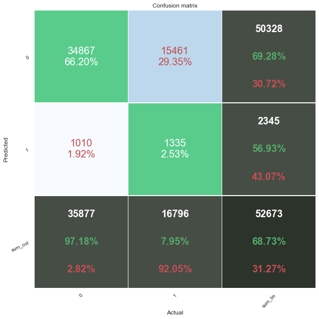

```python
plot_confusion_matrix_from_data(y_test_ctvec, dty_pred_ctvec, columns=[0,1], cmap='Blues', fz=20)
```

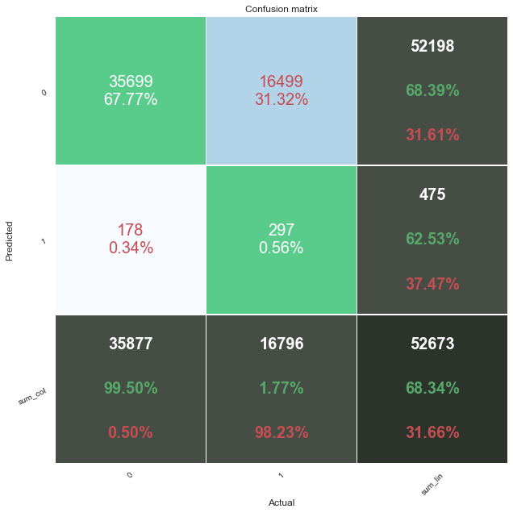

```python
plot_confusion_matrix_from_data(y_test_tfidf, dty_pred_tfidf, columns=[0,1], cmap='Blues', fz=20)
```

#### Random Forest

```python
from sklearn.ensemble import RandomForestClassifier
```

```python
param_dict = {
    'max_depth': [4, 8, 12, 16, 20],
    'min_samples_leaf': [1, 5, 10, 15, 20],
    'random_state': [0]
}
```

```python
rfgrid_ctvec = GridSearchCV(
    RandomForestClassifier(),
    param_grid=param_dict,
    verbose=1,
    n_jobs=4)
rfgrid_ctvec.fit(x_train_ctvec, y_train_ctvec)
```

```
Fitting 5 folds for each of 25 candidates, totalling 125 fits
```

```
GridSearchCV(estimator=RandomForestClassifier(), n_jobs=4,
             param_grid={'max_depth': [4, 8, 12, 16, 20],
                         'min_samples_leaf': [1, 5, 10, 15, 20],
                         'random_state': [0]},
             verbose=1)
```

```python
rfgrid_tfidf = GridSearchCV(
    RandomForestClassifier(),
    param_grid=param_dict,
    verbose=1,
    n_jobs=4)
rfgrid_tfidf.fit(x_train_tfidf, y_train_tfidf)
```

```
Fitting 5 folds for each of 25 candidates, totalling 125 fits
```

```
GridSearchCV(estimator=RandomForestClassifier(), n_jobs=4,
             param_grid={'max_depth': [4, 8, 12, 16, 20],
                         'min_samples_leaf': [1, 5, 10, 15, 20],
                         'random_state': [0]},
             verbose=1)
```

```python
print(rfgrid_ctvec.best_params_)
print(rfgrid_ctvec.best_estimator_)
print(rfgrid_ctvec.best_score_)
```

```
{'max_depth': 20, 'min_samples_leaf': 5, 'random_state': 0}
RandomForestClassifier(max_depth=20, min_samples_leaf=5, random_state=0)
0.6870553282824835
```

```python
print(rfgrid_tfidf.best_params_)
print(rfgrid_tfidf.best_estimator_)
print(rfgrid_tfidf.best_score_)
```

```
{'max_depth': 20, 'min_samples_leaf': 5, 'random_state': 0}
RandomForestClassifier(max_depth=20, min_samples_leaf=5, random_state=0)
0.6884792239090944
```

```python
rfy_pred_ctvec = rfgrid_ctvec.best_estimator_.predict(x_test_ctvec)
rfy_pred_tfidf = rfgrid_tfidf.best_estimator_.predict(x_test_tfidf)
```

```python
print(accuracy_score(y_test_ctvec, rfy_pred_ctvec))
print(accuracy_score(y_test_tfidf, rfy_pred_tfidf))
```

```
0.6872970971845158
0.687828678829761
```

##### CountVectorizer Random Forest Report

```python
print(classification_report(y_test_ctvec, rfy_pred_ctvec))
```

```
              precision    recall  f1-score   support

       False       0.69      0.97      0.81     35877
        True       0.57      0.08      0.14     16796

    accuracy                           0.69     52673
   macro avg       0.63      0.53      0.47     52673
weighted avg       0.65      0.69      0.60     52673
```

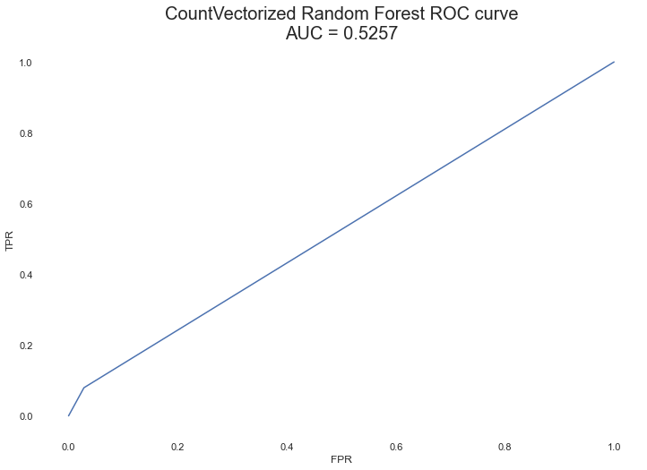

```python
from sklearn.metrics import auc
fpr, tpr, _ = roc_curve(y_test_ctvec, rfy_pred_ctvec)
plt.clf()
plt.plot(fpr, tpr)
plt.xlabel('FPR')
plt.ylabel('TPR')
plt.title('CountVectorized Random Forest ROC curve\nAUC = {:.4f}'.format(
    auc(*roc_curve(y_test_ctvec, rfy_pred_ctvec)[0:2])), fontdict = {'fontsize' : 20})
plt.show()
```

##### TF-IDF Random Forest Report

```python
print(classification_report(y_test_tfidf, rfy_pred_tfidf))
```

```
              precision    recall  f1-score   support

       False       0.69      0.98      0.81     35877
        True       0.58      0.07      0.13     16796

    accuracy                           0.69     52673
   macro avg       0.64      0.52      0.47     52673
weighted avg       0.66      0.69      0.59     52673
```

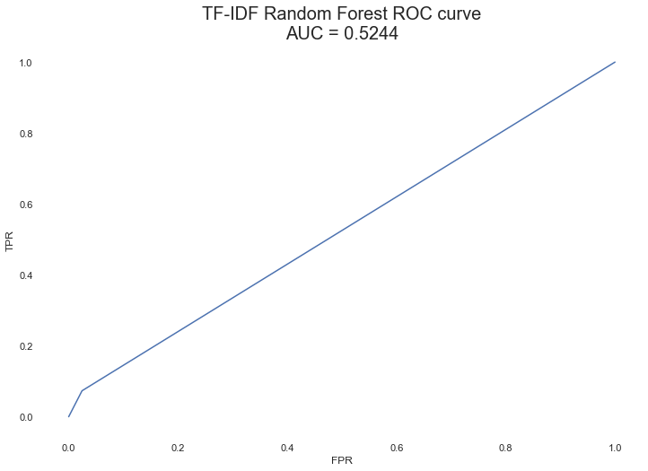

```python
from sklearn.metrics import auc
fpr, tpr, _ = roc_curve(y_test_tfidf, rfy_pred_tfidf)
plt.clf()
plt.plot(fpr, tpr)
plt.xlabel('FPR')
plt.ylabel('TPR')
plt.title('TF-IDF Random Forest ROC curve\nAUC = {:.4f}'.format(
    auc(*roc_curve(y_test_tfidf, rfy_pred_tfidf)[0:2])), fontdict = {'fontsize' : 20})
plt.show()
```

##### CountVectorizer Random Forest Feature Importances

```python
pd.Series(rfgrid_ctvec.best_estimator_.feature_importances_, X_ctvec.columns).sort_values(ascending=False).head(10)
```

```
score                         0.254616
upvote_ratio                  0.216028
num_comments                  0.185179
link_flair_text_Memes         0.061141
link_flair_text_Fluff         0.051292
link_flair_text_Discussion    0.031317
total_awards_received         0.027354
cluster_0                     0.026579
link_flair_text_DD            0.016446
link_flair_text_Shitpost      0.015619
dtype: float64
```

##### TF-IDF Random Forest Feature Importances

```python
pd.Series(rfgrid_tfidf.best_estimator_.feature_importances_, X_tfidf.columns).sort_values(ascending=False).head(10)
```

```
score                         0.251596
upvote_ratio                  0.207115
num_comments                  0.180503
link_flair_text_Memes         0.059924
link_flair_text_Fluff         0.049423
link_flair_text_Discussion    0.031917
total_awards_received         0.029418
cluster_15                    0.024292
cluster_11                    0.022308
link_flair_text_Shitpost      0.015806
dtype: float64
```

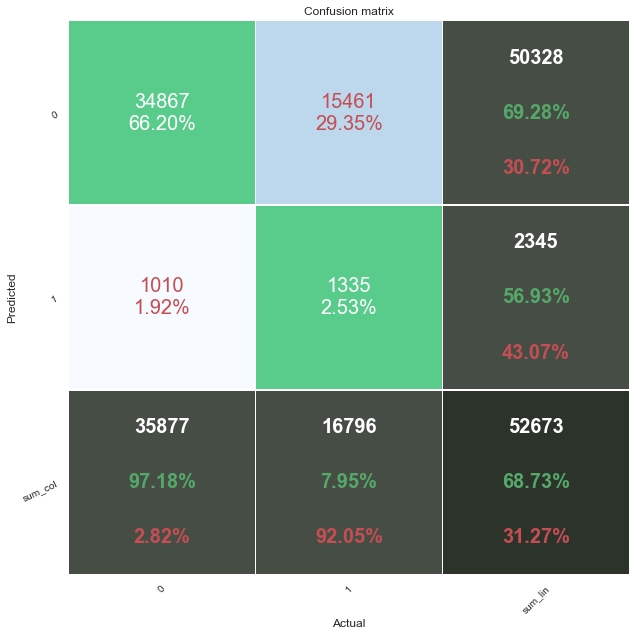

```python
plot_confusion_matrix_from_data(y_test_ctvec, rfy_pred_ctvec, columns=[0,1], cmap='Blues', fz=20)
```

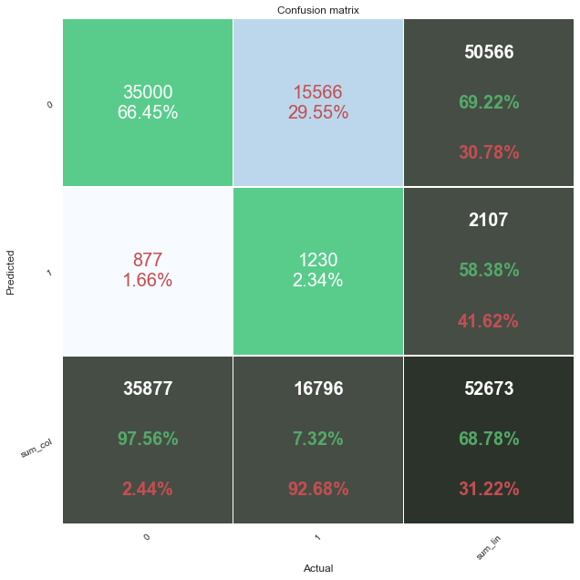

```python
plot_confusion_matrix_from_data(y_test_tfidf, rfy_pred_tfidf, columns=[0,1], cmap='Blues', fz=20)
```